# Case Olist Brasil

Autor

Nathalia Santos

Data de Publicação

25/11/2024

# 1 Processamento e tratamento de dados

> Comentários:
- Deixei o formato comprido (wider) para conseguir representar informações categoricas como numeral de forma mais eficiente e para destrinchar informações das ordens para agrupar por cliente
- Tipo de pagamento indefinido foi usado o tipo mais frequente (Menos frequente: not_defined e Mais frquente: credit_card)
- Pedidos cancelados ou coisas do tipo foram mantidos pois guardam informação parcial de que o cliente ‘estava disposto a comprar tal item’
- Tranformou-se os dados de precificação em log-escala para normalizar os dados:

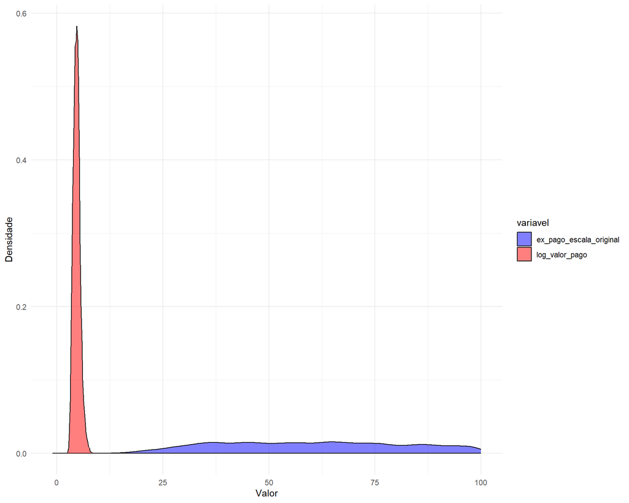

Densidade por tipo de dado

- Por haver poucos clientes que compraram mais de uma vez, e ainda menos que compraram mais de 2 vezes. Algumas vezes optei por tratar como binário: ter sido ou não primeira compra, por exemplo
- Foi usado imputação de dados em alguns momentos para não perder informação

```
RandomForestClassifier(criterion='entropy', n_estimators=10, random_state=1)
```

| Descrição | Antes | Depois |
| --- | --- | --- |
| Categorias de produtos | 74 | 26 |
| Categorias de produtos nulas | 610 | 0 |

> Resumo do que foi usado aqui para prever as classes:
- Método: Floresta Aleatória para classificação
- Acurácia: 86.41%
- Ideia aqui foi usar os dados de avaliação dos produtos para ajudar a melhorar a categorização de qual categoria pertenceria o valores de dimensão do produto (peso, altura, comprimento…)
- Para os dados numéricos que faltavam de informações do anúncio do produto (tamanho do título, quantidade de fotos e tamanho da descrição), usou-se a média. Esses dados entraram na Árvore

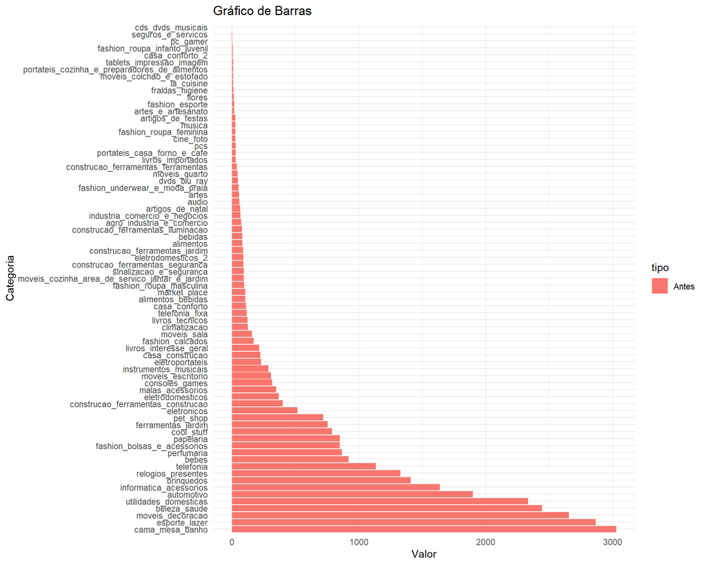

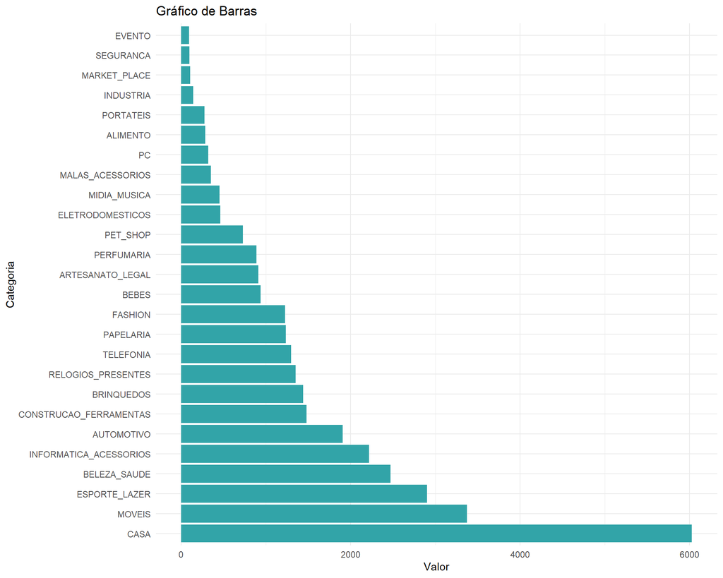

[output not shown]

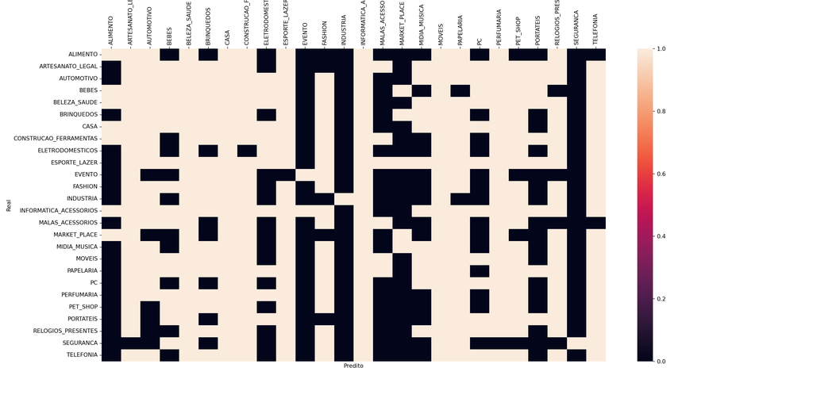

## 1.1 Resumo dados

```
                              count     mean      std  min    25%    50%  \
product_name_lenght         32341.0    48.48    10.25  5.0   42.0   51.0
product_description_lenght  32341.0   771.50   635.12  4.0  339.0  595.0
product_photos_qty          32341.0     2.19     1.74  1.0    1.0    1.0
product_weight_g            32950.0  2276.51  4281.98  0.0  300.0  700.0
product_length_cm           32950.0    30.82    16.91  7.0   18.0   25.0
product_height_cm           32950.0    16.94    13.64  2.0    8.0   13.0
product_width_cm            32950.0    23.20    12.08  6.0   15.0   20.0

                               75%      max
product_name_lenght           57.0     76.0
product_description_lenght   972.0   3992.0
product_photos_qty             3.0     20.0
product_weight_g            1900.0  40425.0
product_length_cm             38.0    105.0
product_height_cm             21.0    105.0
product_width_cm              30.0    118.0
```

```
                  count    mean     std   min    25%    50%     75%      max
order_item_id  112650.0    1.20    0.71  1.00   1.00   1.00    1.00    21.00
price          112650.0  120.65  183.63  0.85  39.90  74.99  134.90  6735.00
freight_value  112650.0   19.99   15.81  0.00  13.08  16.26   21.15   409.68
log_price      112650.0    4.32    0.93 -0.16   3.69   4.32    4.90     8.82
log_frete      112650.0    2.89    0.53  0.00   2.64   2.85    3.10     6.02
```

# 2 Descritiva

> Forma de pagamento do cliente:

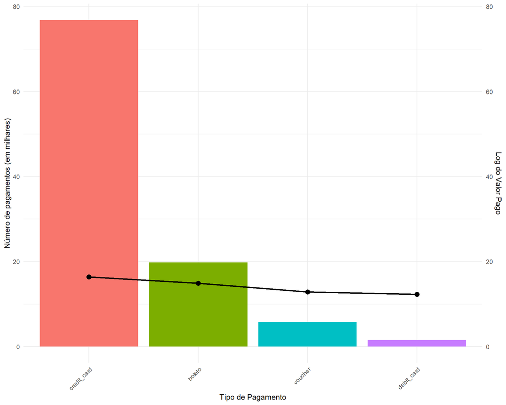

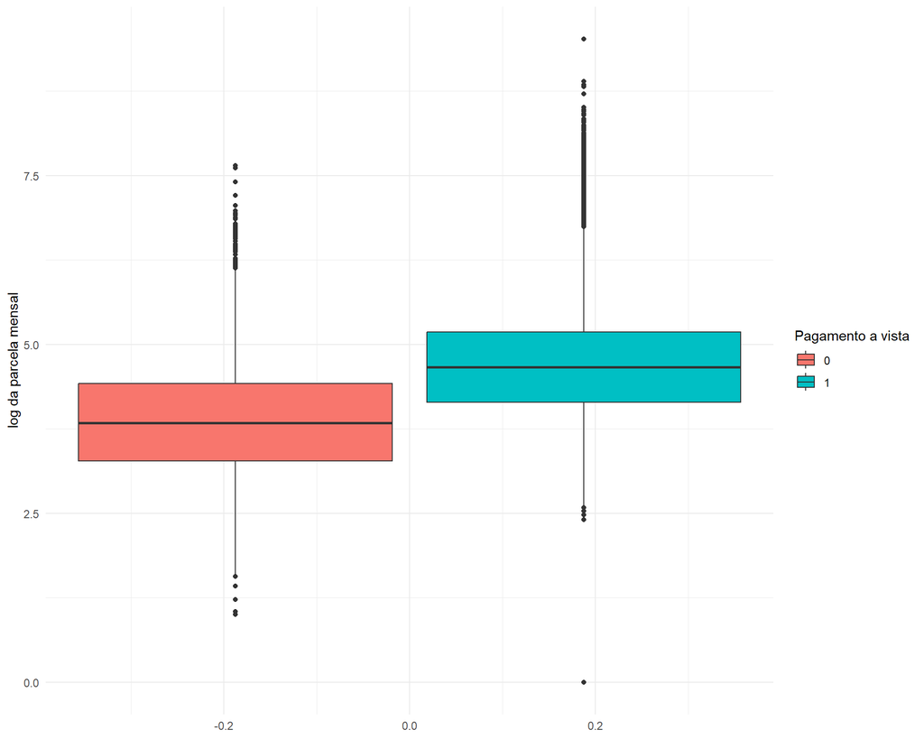

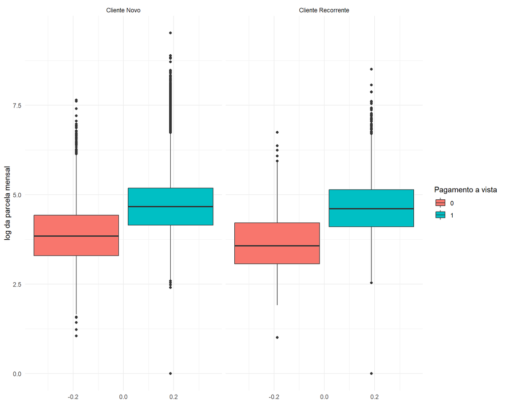

- Aqui parece haver uma possível mudança de comportamento do preço de compra entre a primeira e a segunda compra

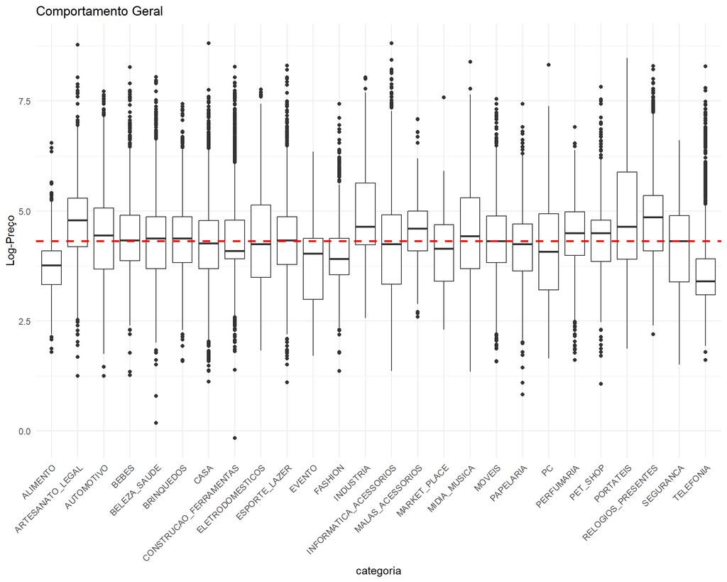

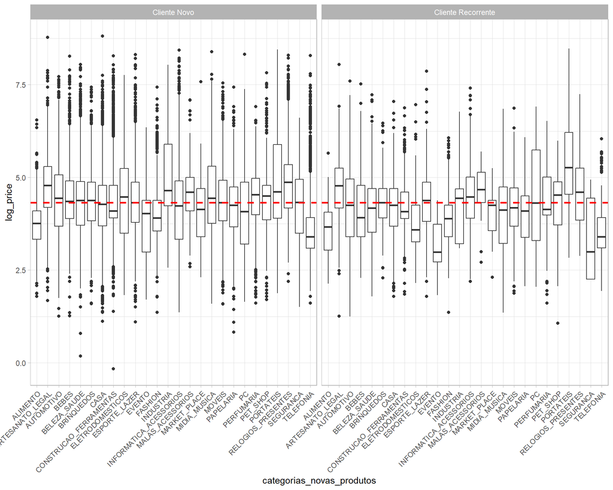

```
  Dia do Pedido  Cliente Novo  Cliente Recorrente
0        Friday         14.26               14.23
1        Monday         16.19               16.27
2      Saturday         11.12               10.91
3        Sunday         12.24               12.03
4      Thursday         15.28               14.82
5       Tuesday         15.38               16.10
6     Wednesday         15.53               15.64
```

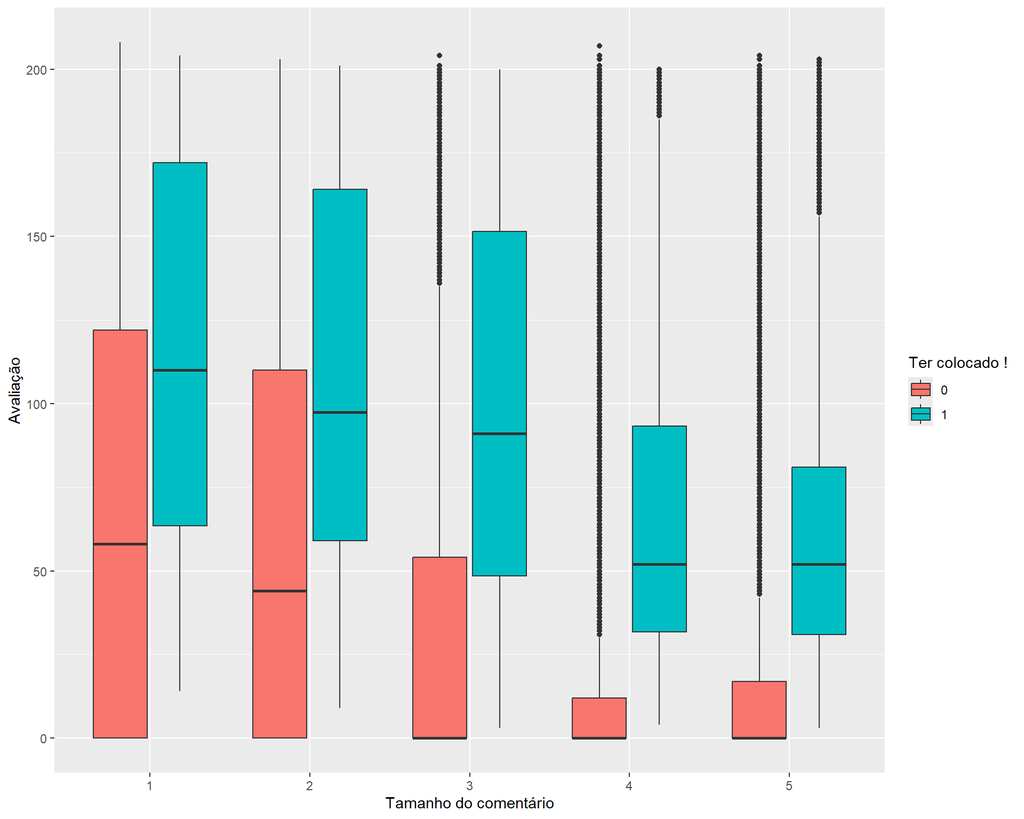

> Itens mais frequentes comprados em um mesmo pedido

```
                          count  mean   std  min  25%  50%  75%   max
ALIMENTO                98663.0  0.01  0.14  0.0  0.0  0.0  0.0  10.0
ARTESANATO_LEGAL        98663.0  0.04  0.21  0.0  0.0  0.0  0.0   7.0
AUTOMOTIVO              98663.0  0.04  0.23  0.0  0.0  0.0  0.0  20.0
BEBES                   98663.0  0.03  0.19  0.0  0.0  0.0  0.0  12.0
BELEZA_SAUDE            98663.0  0.10  0.34  0.0  0.0  0.0  0.0  21.0
BRINQUEDOS              98663.0  0.04  0.22  0.0  0.0  0.0  0.0   6.0
CASA                    98663.0  0.20  0.51  0.0  0.0  0.0  0.0  12.0
CONSTRUCAO_FERRAMENTAS  98663.0  0.06  0.32  0.0  0.0  0.0  0.0  15.0
ELETRODOMESTICOS        98663.0  0.01  0.10  0.0  0.0  0.0  0.0   2.0
ESPORTE_LAZER           98663.0  0.09  0.33  0.0  0.0  0.0  0.0   7.0
EVENTO                  98663.0  0.00  0.06  0.0  0.0  0.0  0.0   6.0
FASHION                 98663.0  0.03  0.18  0.0  0.0  0.0  0.0   6.0
INDUSTRIA               98663.0  0.00  0.08  0.0  0.0  0.0  0.0   6.0
INFORMATICA_ACESSORIOS  98663.0  0.11  0.38  0.0  0.0  0.0  0.0  20.0
MALAS_ACESSORIOS        98663.0  0.01  0.11  0.0  0.0  0.0  0.0   5.0
MARKET_PLACE            98663.0  0.00  0.07  0.0  0.0  0.0  0.0   6.0
MIDIA_MUSICA            98663.0  0.01  0.12  0.0  0.0  0.0  0.0   6.0
MOVEIS                  98663.0  0.11  0.43  0.0  0.0  0.0  0.0  15.0
PAPELARIA               98663.0  0.03  0.20  0.0  0.0  0.0  0.0   6.0
PC                      98663.0  0.01  0.12  0.0  0.0  0.0  0.0   6.0
PERFUMARIA              98663.0  0.04  0.21  0.0  0.0  0.0  0.0   6.0
PET_SHOP                98663.0  0.02  0.16  0.0  0.0  0.0  0.0   7.0
PORTATEIS               98663.0  0.01  0.10  0.0  0.0  0.0  0.0   6.0
RELOGIOS_PRESENTES      98663.0  0.06  0.26  0.0  0.0  0.0  0.0  12.0
SEGURANCA               98663.0  0.00  0.06  0.0  0.0  0.0  0.0   6.0
TELEFONIA               98663.0  0.05  0.25  0.0  0.0  0.0  0.0  14.0
itens_por_ordem         98663.0  1.14  0.54  1.0  1.0  1.0  1.0  21.0
```

## 2.1 Teste de Hipótese

**Ponto alvo**

Variáveis que contribuiem para o aumento do valor de compra dos clientes

- Conclusão aqui é que oferecer voucher não gera efeito significativo no aumento do valor que o cliente gasta na **Olist**.

| Covariável | gl | SQ | MQ | F | Pvalor |
| --- | --- | --- | --- | --- | --- |
| Log_frete | 1 | 16,941.942 | 16,941.942 | 27825.176 | <0.001* |
| Soma_tipos_pagamentos | 1 | 550.725 | 550.725 | 904.502 | <0.001* |
| Boleto | 1 | 82.508 | 82.508 | 135.509 | <0.001* |
| Credit_card | 2 | 24.910 | 12.455 | 20.456 | <0.001* |
| Debit_card | 1 | 1.423 | 1.423 | 2.338 | 0.126 |
| Pago_a_vista | 1 | 15.592 | 15.592 | 25.608 | <0.001* |
| Dia_pedido | 6 | 19.166 | 3.194 | 5.246 | <0.001* |
| Regiao_cliente | 4 | 924.780 | 231.195 | 379.711 | <0.001* |
| Len_titulo | 1 | 6.834 | 6.834 | 11.224 | 0.001* |
| Volume_prod | 1 | 2,454.738 | 2,454.738 | 4031.623 | <0.001* |
| Categorias_novas_produtos | 25 | 6,331.268 | 253.251 | 415.935 | <0.001* |
| Review_score | 4 | 35.919 | 8.980 | 14.748 | <0.001* |
| Primeira_compra_cliente | 1 | 24.559 | 24.559 | 40.336 | <0.001* |
| Voucher | 1 | 0.978 | 0.978 | 1.607 | 0.205 |
| Categorias_novas_produtos : Primeira_compra_cliente | 25 | 164.906 | 6.596 | 10.834 | <0.001* |
| Residuals | 112,293 | 68,371.949 | 0.609 |  |  |

Significativo a 5% de significância e '.' significativo a 10%

```
Analysis of Variance Table

Model 1: log_price ~ log_frete + soma_tipos_pagamentos + boleto + credit_card +
    debit_card + pago_a_vista + dia_pedido + regiao_cliente +
    len_titulo + volume_prod + categorias_novas_produtos + review_score +
    primeira_compra_cliente * categorias_novas_produtos + voucher
Model 2: log_price ~ log_frete + soma_tipos_pagamentos + boleto + credit_card +
    debit_card + pago_a_vista + dia_pedido + regiao_cliente +
    len_titulo + volume_prod + categorias_novas_produtos + review_score +
    primeira_compra_cliente + categorias_novas_produtos:primeira_compra_cliente
  Res.Df   RSS Df Sum of Sq      F Pr(>F)
1 112293 68372
2 112294 68373 -1  -0.92483 1.5189 0.2178
```

### 2.1.1 Qual categoria está contribuindo mais para o valor gasto do cliente?

**Dica**

**Possíveis Estratégias para vender mais itens de Pet-Shop:**

- Parece que o cliente alvo para os itens de pet-shop, gasta mais com esses itens depois que estão com seus itens básicos já adquiridos em suas primeiras compras. Depois de garantir seus itens básicos e gastar com seus pets, esse cliente está mais apto a gastar mais com artesanato, ‘coisas legais’ e itens de viagem, por exemplo.

| Fator1 | Fator2 | Diferença | Pvalor |
| --- | --- | --- | --- |
| ALIMENTO - PET_SHOP | 1 : 0 | -0.531 | <0.001* |
| ARTESANATO_LEGAL - PET_SHOP | 1 : 0 | 0.385 | 0.002* |
| EVENTO - PET_SHOP | 1 : 0 | -0.597 | <0.001* |
| INDUSTRIA - PET_SHOP | 1 : 0 | 0.554 | <0.001* |
| PET_SHOP - ALIMENTO | 0 : 0 | 0.631 | <0.001* |
|  | 1 : 0 | 0.670 | <0.001* |
|  | 1 : 1 | 0.570 | <0.001* |
| PET_SHOP - ARTESANATO_LEGAL | 1 : 0 | -0.271 | 0.091. |
|  | 1 : 1 | -0.346 | <0.001* |
| PET_SHOP - BELEZA_SAUDE | 1 : 0 | 0.191 | 0.003* |
| PET_SHOP - CASA | 1 : 0 | 0.173 | <0.001* |
|  | 1 : 1 | 0.107 | 0.001* |
| PET_SHOP - ELETRODOMESTICOS | 0 : 0 | 0.510 | 0.001* |
|  | 1 : 0 | 0.549 | <0.001* |
|  | 1 : 1 | -0.144 | 0.070. |
| PET_SHOP - EVENTO | 1 : 1 | 0.635 | <0.001* |
| PET_SHOP - FASHION | 0 : 0 | 0.461 | 0.001* |
|  | 1 : 0 | 0.500 | <0.001* |
|  | 1 : 1 | 0.314 | <0.001* |
| PET_SHOP - INDUSTRIA | 1 : 1 | -0.515 | <0.001* |
| PET_SHOP - INFORMATICA_ACESSORIOS | 1 : 1 | 0.207 | <0.001* |
| PET_SHOP - MALAS_ACESSORIOS | 1 : 1 | -0.261 | <0.001* |
| PET_SHOP - MARKET_PLACE | 1 : 1 | 0.220 | 0.060. |
| PET_SHOP - MIDIA_MUSICA | 1 : 1 | -0.224 | <0.001* |
| PET_SHOP - MOVEIS | 1 : 0 | 0.188 | <0.001* |
| PET_SHOP - PAPELARIA | 1 : 0 | 0.380 | <0.001* |
|  | 1 : 1 | 0.183 | <0.001* |
| PET_SHOP - PC | 1 : 1 | 0.142 | 0.024* |
| PET_SHOP - PORTATEIS | 1 : 0 | -0.799 | <0.001* |
| PET_SHOP - RELOGIOS_PRESENTES | 1 : 0 | -0.249 | 0.002* |
| PET_SHOP - TELEFONIA | 1 : 0 | 0.698 | <0.001* |
| PORTATEIS - PET_SHOP | 0 : 0 | 0.838 | 0.001* |
|  | 1 : 0 | 0.567 | <0.001* |
|  | 1 : 1 | 0.528 | <0.001* |
| RELOGIOS_PRESENTES - PET_SHOP | 1 : 0 | 0.526 | <0.001* |
|  | 1 : 1 | 0.487 | <0.001* |
| TELEFONIA - PET_SHOP | 0 : 0 | -0.659 | <0.001* |
|  | 1 : 0 | -0.646 | <0.001* |
|  | 1 : 1 | -0.685 | <0.001* |

Nota: Fator1 refere a NA  
* significativo a 5% de significância e '.' significativo a 10%

**Abaixo será feita uma análise marginal de pet-shop, ou seja, desconsiderando a ordem da compra:**

Aqui vemos uma análise mais direta do que já foi concluído acima:

- Gasta-se mais com Pet-shop em relação a itens de consumo domésticos
- Gasta-se menos com Pet-shop em relação a itens de desejo, como artigos de viagem e artesanato

| Fator1 | Diferença | Pvalor |
| --- | --- | --- |
| PET_SHOP - ALIMENTO | 0.576 | <0.001* |
| PET_SHOP - ARTESANATO_LEGAL | -0.345 | <0.001* |
| PET_SHOP - CASA | 0.110 | <0.001* |
| PET_SHOP - EVENTO | 0.655 | <0.001* |
| PET_SHOP - FASHION | 0.336 | <0.001* |
| PET_SHOP - INDUSTRIA | -0.489 | <0.001* |
| PET_SHOP - INFORMATICA_ACESSORIOS | 0.187 | <0.001* |
| PET_SHOP - MALAS_ACESSORIOS | -0.263 | <0.001* |
| PET_SHOP - MARKET_PLACE | 0.218 | 0.015* |
| PET_SHOP - MIDIA_MUSICA | -0.203 | <0.001* |
| PET_SHOP - PAPELARIA | 0.190 | <0.001* |
| PET_SHOP - PC | 0.131 | 0.018* |
| PORTATEIS - PET_SHOP | 0.542 | <0.001* |
| RELOGIOS_PRESENTES - PET_SHOP | 0.476 | <0.001* |
| TELEFONIA - PET_SHOP | -0.683 | <0.001* |

Nota: Fator1 refere a categorias_novas_produtos %>% filter(grepl("PET_SHOP",  
* significativo a 5% de significância e '.' significativo a 10%

## 2.2 Outras análises mais diretas:

### 2.2.1 Gasto vs Avaliação

- Clientes que gastam mais ou em produtos mais caros tendem a gostar mais de sua experiência de compra
- **Clientes que avaliam em nota máxima e mínima gastam de forma igual. Isso pode ser indicativo que há outras variáveis que se associam ao gasto e a satisfação do cliente**

| Fator1 | Diferença | Pvalor |
| --- | --- | --- |
| 2 - 1 | -0.041 | 0.074. |
| 3 - 1 | -0.044 | 0.002* |
| 4 - 2 | 0.040 | 0.075. |
| 4 - 3 | 0.042 | 0.001* |
| 5 - 2 | 0.040 | 0.050* |
| 5 - 3 | 0.042 | <0.001* |

Nota: Fator1 refere a review_score  
* significativo a 5% de significância e '.' significativo a 10%

### 2.2.2 Gasto vs Primeira compra

| Fator1 | Diferença | Pvalor |
| --- | --- | --- |
| 1 - 0 | 0.095 | <0.001* |

Nota: Fator1 refere a primeira_compra_cliente  
* significativo a 5% de significância e '.' significativo a 10%

### 2.2.3 Gasto vs Região

Em relação aos gastos:

$$NorteNordeste > Sudeste-SP = Centro-Oeste > Sul > SP$$

- Nesse caso, também indicou que $Sudeste-SP = Sul$ mas $Centro-Oeste \neq Sul$ o que é um pouco contraintuitivo, mas talvez numa amostra maior, ou considerando interações, seria possível afirmar em quais condições faz com que Centro-Oeste e Sul se diferenciem.

| Fator1 | Diferença | Pvalor |
| --- | --- | --- |
| NorteNordeste - Centro_Oeste | 0.085 | <0.001* |
| SP - Centro_Oeste | -0.142 | <0.001* |
| SP - NorteNordeste | -0.228 | <0.001* |
| Sudeste_SP - NorteNordeste | -0.111 | <0.001* |
| Sudeste_SP - SP | 0.116 | <0.001* |
| Sul - Centro_Oeste | -0.043 | 0.019* |
| Sul - NorteNordeste | -0.128 | <0.001* |
| Sul - SP | 0.099 | <0.001* |

Nota: Fator1 refere a regiao_cliente  
* significativo a 5% de significância e '.' significativo a 10%

### 2.2.4 Gasto vs Dia da compra

Domingo é o pior dia de compra, quando pensa-se em gasto médio, seguido por sábado.

| Fator1 | Diferença | Pvalor |
| --- | --- | --- |
| Sunday - Friday | -0.028 | 0.098. |
| Sunday - Monday | -0.044 | <0.001* |
| Sunday - Saturday | -0.037 | 0.017* |
| Thursday - Sunday | 0.029 | 0.077. |
| Tuesday - Sunday | 0.032 | 0.022* |
| Wednesday - Sunday | 0.031 | 0.038* |

Nota: Fator1 refere a dia_pedido  
* significativo a 5% de significância e '.' significativo a 10%

### 2.2.5 Gasto vs Forma de pagamento

- Pessoas que optam por boleto, gastam menos

| Fator1 | Diferença | Pvalor |
| --- | --- | --- |
| 1 - 0 | -0.152 | <0.001* |

Nota: Fator1 refere a boleto  
* significativo a 5% de significância e '.' significativo a 10%

- Pessoas que optam por cartão de crédito e a usam em mais parcelas, gastam mais

| Fator1 | Diferença | Pvalor |
| --- | --- | --- |
| 1 - 0 | 0.046 | <0.001* |
| 2 - 0 | 0.607 | <0.001* |
| 2 - 1 | 0.560 | <0.001* |

Nota: Fator1 refere a credit_card  
* significativo a 5% de significância e '.' significativo a 10%

- Pessoas que optam por cartão de débito, gastam mais

| Fator1 | Diferença | Pvalor |
| --- | --- | --- |
| 1 - 0 | 0.119 | <0.001* |

Nota: Fator1 refere a debit_card  
* significativo a 5% de significância e '.' significativo a 10%

**Dica**

**Possíveis Estratégias para vender mais itens de Pet-Shop nas demais análises:**

- Incentivar o uso do cartão de crédito e o parcelamento da compra poderia gerar mais oportunidade do cliente gastar mais na loja. Promoções no meio de semana são igualmente eficazes para aumentar o ticket-médio do cliente. Aproveitar a primeira compra do cliente para arrecadar mais em sua compra, mas também garantir que ele volte para gastar com itens de desejo ao invés de apenas artigos de necessidade imediata refletirão de forma positiva no gasto do cliente na loja. Por fim, aumentar a exposição no mercado Norte-Nordeste parece gerar um crescimento mais significativo que nas demais regiões.

# 3 Agrupamento de clientes

- Usando todas variáveis, não alcançou explicabilidade mínima na variabilidade de pelo menos uma componente optei por tratar da PCA com as variáveis mais correlacionadas. Ganho:

| Tipo e Cenário | Pior (todas variáveis) | Melhorado (mais correlacionadas) |
| --- | --- | --- |
| Perc valor esperado mínimo componente | 13.74 | 25.82 |
| Perc melhor componente | 9.1 | 30.67 |

```
    per_var_acum   comp
0      30.672872   pca0
1      44.075522   pca1
2      56.938936   pca2
3      68.039287   pca3
4      78.143765   pca4
5      84.341199   pca5
6      88.603680   pca6
7      91.653493   pca7
8      94.409700   pca8
9      96.558924   pca9
10     97.989491  pca10
11     98.834258  pca11
12     99.624505  pca12
13     99.898941  pca13
14    100.000000  pca14
```

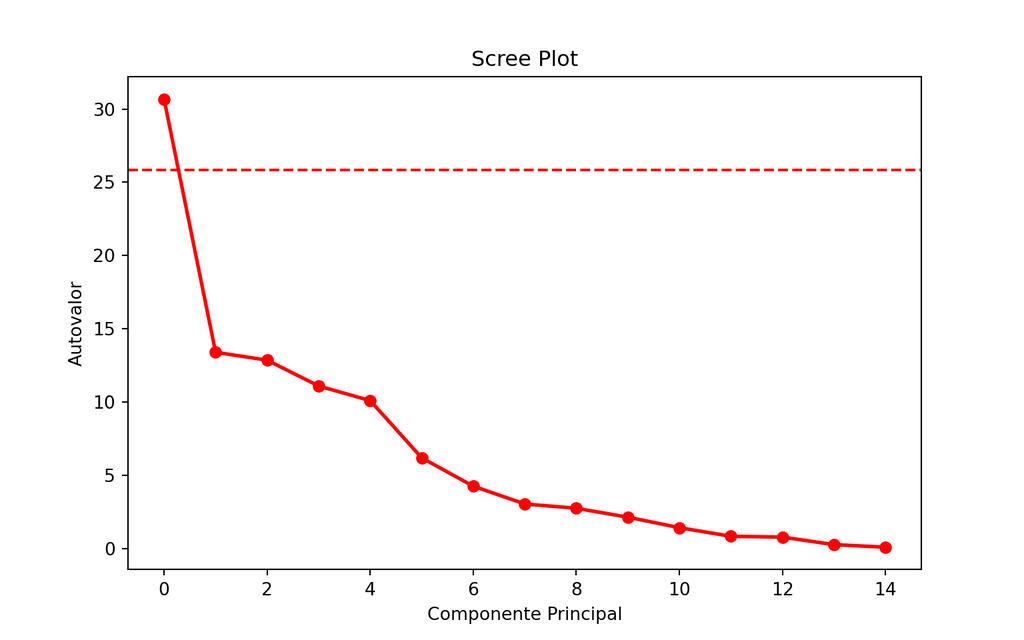

```
                  c1             c2
count  112369.000000  112369.000000
mean     6564.994973   -2550.650837
std     10003.531751    3894.804211
min       162.840284  -48024.752667
25%      1265.312841   -3022.549736
50%      2860.556557   -1104.033895
75%      7849.802185    -483.573701
max    122570.348007     -49.436006
```

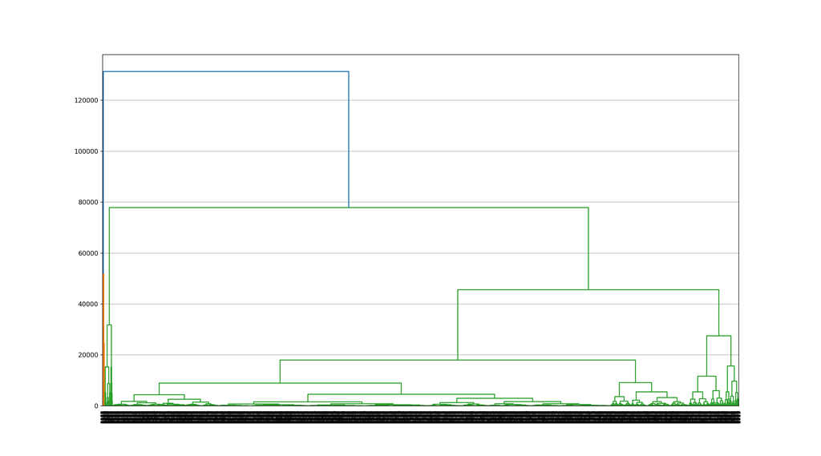

> Dos clientes únicos, o percentual alocado em cada cluster foi:

```
grupo
0     3.56
1    85.63
2    10.81
dtype: float64
```

> Como se comportam em média nas compras

```
   grupo  colocou_titulo  len_titulo  len_comentario  colocou_exc  \
0      0        0.183219    1.652397       42.299658     0.039384
1      1        0.124506    1.527062       32.103058     0.053039
2      2        0.116529    1.600380       39.369221     0.055731

   credit_card  tempo_conf_pedido  atraso_prev_entrega  product_photos_qty  \
0     0.827055           0.275685             0.077055            1.766475
1     0.754007           0.345412             0.079520            2.112297
2     0.747308           0.329322             0.089297            2.142432

   product_name_lenght  product_description_lenght   volume_prod  \
0            46.890981                  962.723256  95501.123288
1            48.503589                  804.276026   8074.499032
2            49.770669                  662.666951  41779.766308

   md_log_price  sd_log_price  review_score_maximo
0      5.176020      0.838029             3.678082
1      4.137964      0.915772             3.914983
2      4.698682      0.732705             3.787207
```

# 4 Fim